# Soil Available Water Storage Simulation

J.J. Maynard

This R Notebook describes and demonstrates soil simulation modeling of SSURGO soil property data, leveraging sources of know uncertainty to better estimate the potential variability of soil properties, including both primary (e.g., texture, rock fragments) and derived using pedotransfer functions (e.g., PAWHC), and the propogation of uncertainty when generating derived data.

# Coweeta Soil Data Processing Code: Dylan Beaudette (lns 34-150)

## Input Data:

- Coweeta watershed outlines (UTM z17)
- FY23 RSS grid (NC, EPSG:5070)
- FY23 SSURGO polygons (SDA, WGS84)

## Output Data (UTM z17):

- RSS 10m grid
- SSURGO 10m grid
- SSURGO original polygons
- RSS + SSURGO tabular data as SPC

## Notes:

- “Coweeta_Final_raster.tif” is a non-standard packaging of the RSS
- Grid cells are non-standard keys -> RAT -> [musym] -> mapunit -> [mukey]
  - Use FY23 RSS instead: 10m grid via WCS
  - Tabular RSS data via local download
- DEM and derivatives will work on a larger area for complete basin characterization

### Coweeta Laboratory Watersheds (outline)

```r
# Load Coweeta watershed outline (UTM z17 NAD83)
o <- vect(here('data/vect/Coweeta_Hydrologic_Laboratory.shp'))

# Extend by 200m to ensure a tight crop
b <- buffer(o, width = 200)
```

### Get Latest RSS via WCS

```r
# Fetch RSS via WCS, map unit keys as cell values
rss <- mukey.wcs(b, db = 'rss', res = 10)
```

```
 Downloaded 5432 bytes...
 Downloaded 21808 bytes...
 Downloaded 38176 bytes...
 Downloaded 69544 bytes...
 Downloaded 96588 bytes...
```

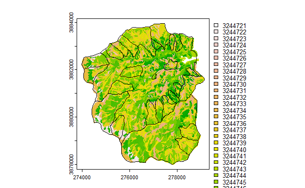

```r
# Project to UTM z17
rss <- project(rss, crs(o), method = 'near')

# Crop to watershed boundaries + 200m
rss <- crop(rss, b)

# Plot to check
plot(rss)
lines(o)
```

```r
# Save for later, includes .xml file with RAT
writeRaster(rss, filename = here('data/grids/rss_utm.tif'), overwrite = TRUE)
```

### Get Latest SSURGO via SDA

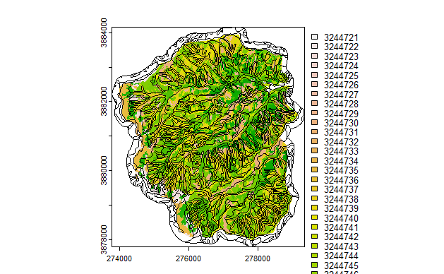

```r
# Get SSURGO polygons for the extended watershed area
s <- SDA_spatialQuery(b, what = 'mupolygon', geomIntersection = TRUE)

# Handle SDA errors
if(inherits(s, 'try-error')) {
  stop('SDA returned an error', call. = FALSE)
}

# Transform to UTM z17
s <- project(s, crs(o))

# Save polygons
writeVector(s, filename = here('data/vect/SSURGO-MU.shp'), overwrite = TRUE)

# Check polygons with RSS
plot(rss)
lines(s)
```

### Rasterize SSURGO Using RSS Grid

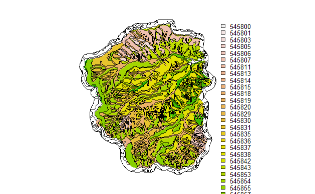

```r
# Rasterize SSURGO data using RSS grid system
s.rast <- rasterize(s, rss, field = 'mukey')

# Crop and mask to RSS data
s.rast <- mask(crop(s.rast, rss), rss)

# Initialize RAT
s.rast <- as.factor(s.rast)

# Fix names in RAT
set.names(s.rast, 'mukey')
rat <- cats(s.rast)[[1]]
levels(s.rast) <- rat

# Plot to check
plot(s.rast, axes = FALSE)
lines(s)
```

```r
# Save raster with RAT
writeRaster(s.rast, filename = here('data/grids/ssurgo_utm.tif'), overwrite = TRUE)
```

### Load FY23 RSS Tabular Data

### Note: RSS data is not currently accessible via SDA

```r
# Load local RSS data
.rss_path <- here('data/RSS/RSS_NC.gdb')
st_layers(.rss_path)

# Load relevant tables
rss.mu <- st_read(.rss_path, layer = 'mapunit')
rss.co <- st_read(.rss_path, layer = 'component')
rss.hz <- st_read(.rss_path, layer = 'chorizon')

# Extract RAT from RSS
rat <- cats(rss)[[1]]

# Check for missing mukeys
setdiff(rat$mukey, rss.mu$mukey)
setdiff(rss.mu$mukey, rat$mukey)

# Subset RSS tables
rss.mu <- rss.mu[rss.mu$mukey %in% rat$mukey, ]
rss.co <- rss.co[rss.co$mukey %in% rss.mu$mukey, ]
rss.hz <- rss.hz[rss.hz$cokey %in% rss.co$cokey, ]

# Save raw tabular data
save(rss.mu, rss.co, rss.hz, file = here('data/rss-tab-data-raw.rda'))
```

# Step 1: Simulate synthetic soil profile instances from the joint-probability distribution of soil properties required to calculate available soil water storage.